# Case Study 6: It’s about time

Devin W. H.

March 22, 2022

```r
data <- rio::import('https://byuistats.github.io/M335/data/sales.csv')
```

## Background

Record of transactions were obtained from several businesses in various industries. The purpose is to identify which business has performed the best within a three month period for a loan program. No forecasting will be conducted, but only an analysis of current time series on the revenue of several businesses from May to July.

## Data Wrangling

```r
data <- data %>%
  mutate(Time = with_tz(Time, tzone = 'America/Denver')) %>%
  filter(!Name == 'Missing')
```

```r
# Provide visualizations that show gross revenue over time for each company (Choose if you want to aggregate at the daily, the weekly, or the monthly level).

sales1 <- data %>%
  mutate(Month = month(Time, label = TRUE), Year = year(Time)) %>%
  group_by(Name, Month) %>%
  summarise(Gross = sum(Amount)) %>%
  filter(!Month == 'Apr') # Only two instances of April transactions
```

```r
# Provide a visualization that gives insight into hours of operation for each company.

sales2 <- data %>%
  mutate(Hour = hour(Time)) %>%
  count(Name, Hour)
```

```r
# We don’t have employee numbers, but customer traffic (number of transactions) may be helpful. Provide a visualization on customer traffic for each company.

sales3 <- data %>%
  mutate(rnd_day = floor_date(Time, unit = 'day')) %>%
  count(Name, rnd_day)
```

## Data Visualization

The following graph shows *gross revenue* for each company monthly. June saw the biggest increase in profits from the previous months with July being slightly more profitable than June for LeBelle.

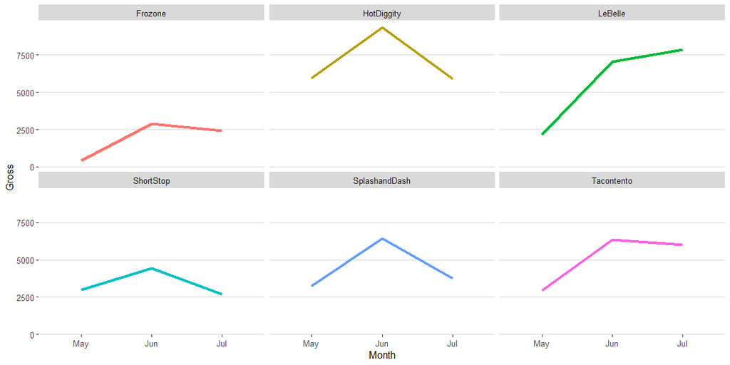

```r
# Provide visualizations that show gross revenue over time for each company (Choose if you want to aggregate at the daily, the weekly, or the monthly level).

ggplot(sales1) +
  aes(x = Month, y = Gross, color = Name) +
  facet_wrap(~Name) +
  geom_line(aes(group = Name), size = 1.5) +
  theme_hc() +
  theme(legend.position = 'None')
```

The graph below finds number of transactions for each store during each hour of the day. Most businesses find the most profitable times to be between 10 and 3 which is expected to be the busiest time frame regardless of industry. It isn’t clear what hours the stores open or close since this only gathers transactions.

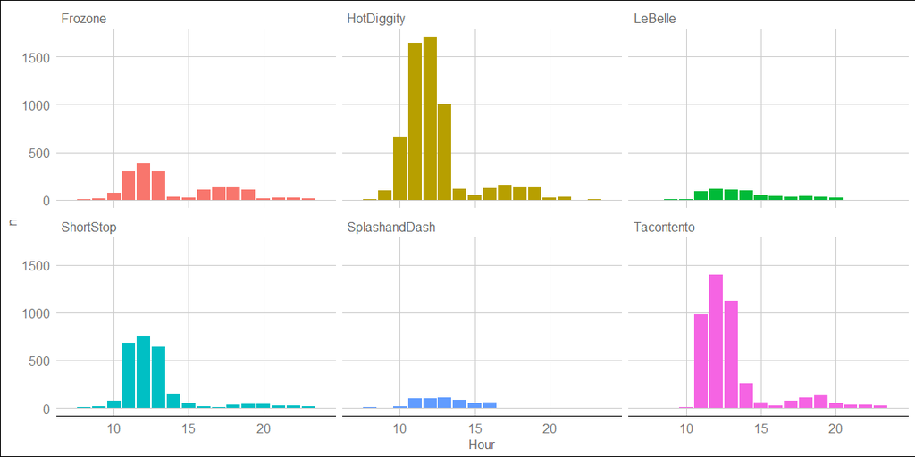

```r
# Provide a visualization that gives insight into hours of operation for each company.

ggplot(sales2) +
  aes(x = Hour, y = n, fill = Name) +
  facet_wrap(~ Name) +
  geom_col() +
  coord_cartesian(xlim = c(7, 24)) +
  theme_gdocs() +
  theme(legend.position = 'None')
```

Down below is daily transactions for customer traffic at each business. Frozone, LeBelle, SplashAndDash, and Tacontento stay mostly similar throughout the months while HotDiggity and Shortstop fluctuate more frequently.

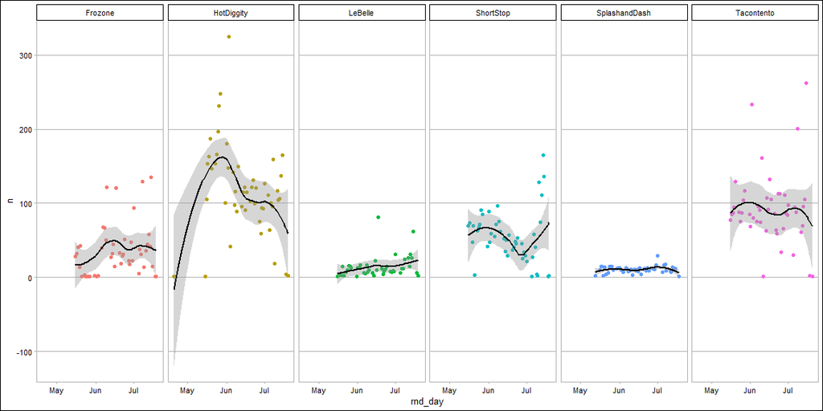

```r
# We don’t have employee numbers, but customer traffic (number of transactions) may be helpful. Provide a visualization on customer traffic for each company.

ggplot(sales3) +
  aes(x = rnd_day, y = n, color = Name) +
  facet_wrap(~ Name, nrow = 1) +
  geom_point() +
  geom_smooth(color = 'black') +
  theme_calc() +
  theme(legend.position = 'None')
```